# Gas Price Sub Markets

2018-12-10

## Thesis

*To what extent are submarkets in gasoline prices segmented accross distinct geographic teritories?*

## Problem Overview

Gasoline markets are very local. While there is correlation in price over time between cities this is almost entirely due to crude oil and refining costs. NYC is correlated with Calgary to some extent, but not when you look at margins.

## Gas Markets

- Gas prices are highly competitive
- The price payed for gasoline only contains a bit of profit for the station
- Margins of 0 to 10% are the norm.
- There is significant fluctiation throught the day and year

## Submarkets

Markets become much less correlated when you compare margins than when you compare prices.

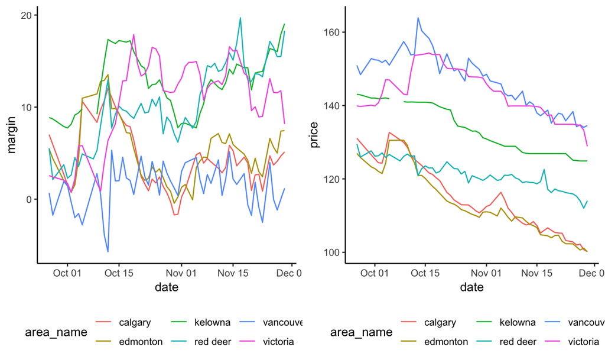

## Correlation

**Prices**

```
##           calgary edmonton kelowna red deer vancouver victoria
## calgary      1.00     0.99    0.95     0.94      0.85     0.56
## edmonton     0.99     1.00    0.93     0.94      0.85     0.54
## kelowna      0.95     0.93    1.00     0.92      0.90     0.66
## red deer     0.94     0.94    0.92     1.00      0.84     0.56
## vancouver    0.85     0.85    0.90     0.84      1.00     0.82
## victoria     0.56     0.54    0.66     0.56      0.82     1.00
```

## Correlation

**Margins**

```
##           calgary edmonton kelowna red deer vancouver victoria
## calgary      1.00     0.92    0.45     0.03     -0.22    -0.25
## edmonton     0.92     1.00    0.51     0.23     -0.22    -0.21
## kelowna      0.45     0.51    1.00     0.67     -0.03     0.35
## red deer     0.03     0.23    0.67     1.00      0.13     0.57
## vancouver   -0.22    -0.22   -0.03     0.13      1.00     0.51
## victoria    -0.25    -0.21    0.35     0.57      0.51     1.00
```

so while there is some correlation, it’s not nearly as distinct as with prices.

## Existing Literature

Much work has been done analyzing gasoline markets because they are highly visible and people spend a lot of money on gas.

Existing literature focused on small sample sizes (although considerably more accurate than mine) and spatial regression.

## My Approach

### Python

- Scrape GasBuddy.com
  - Python/AWS/Selenium/Lots of errors
- Pull location info from google maps API
  - I had grandiouse ideas to scrape weather and traffic but due to budget limitations, I did not
  - Python
- Manipulate data using Pandas Resample

## My Approach

### R

I used data.table and TSclust to cluster time series data using correlation and eucludian distance. I then picked the number of clusters and used this as ‘arbitrary’ labes.

I then split this into train and test sets and performed KNN classification on this using latitude and longitude.

## Graphs

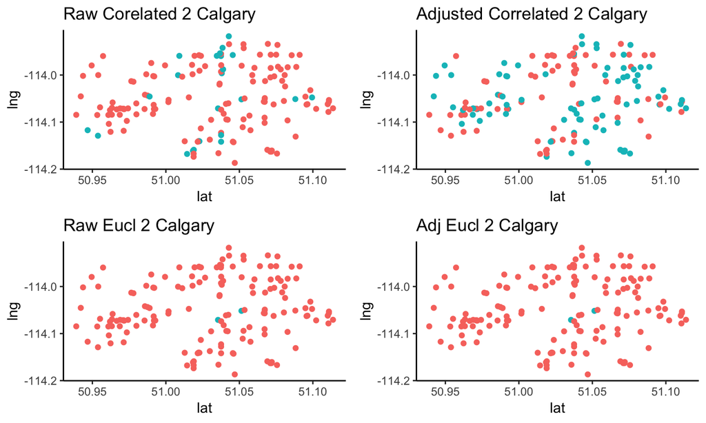

## Calgary 5 Sites

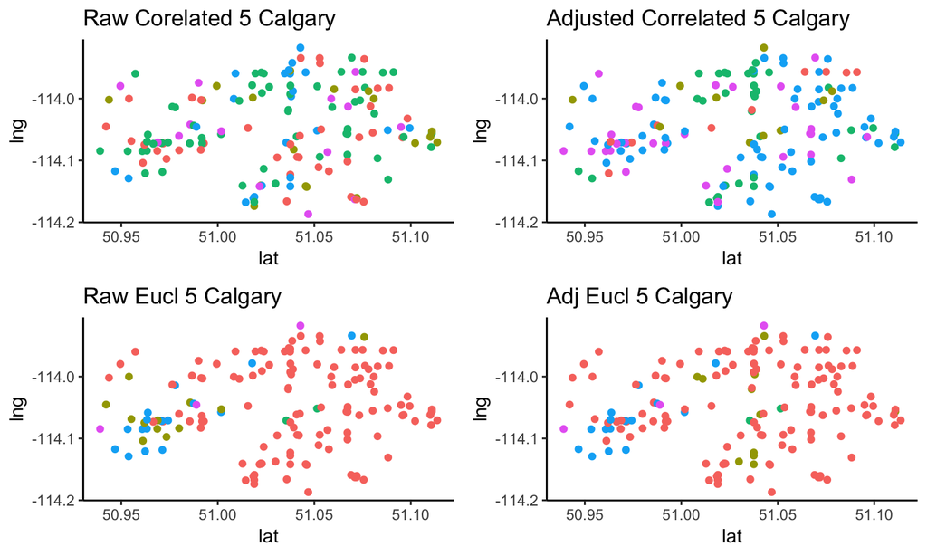

## Western Canada Combined

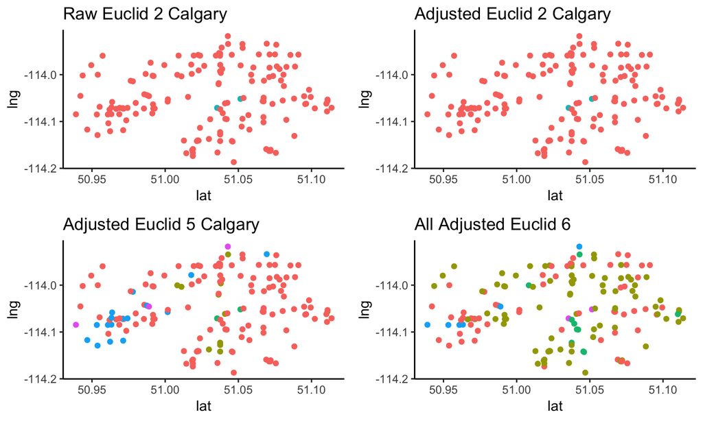

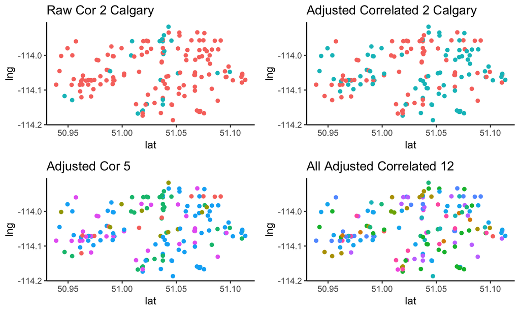

## Best Clustering

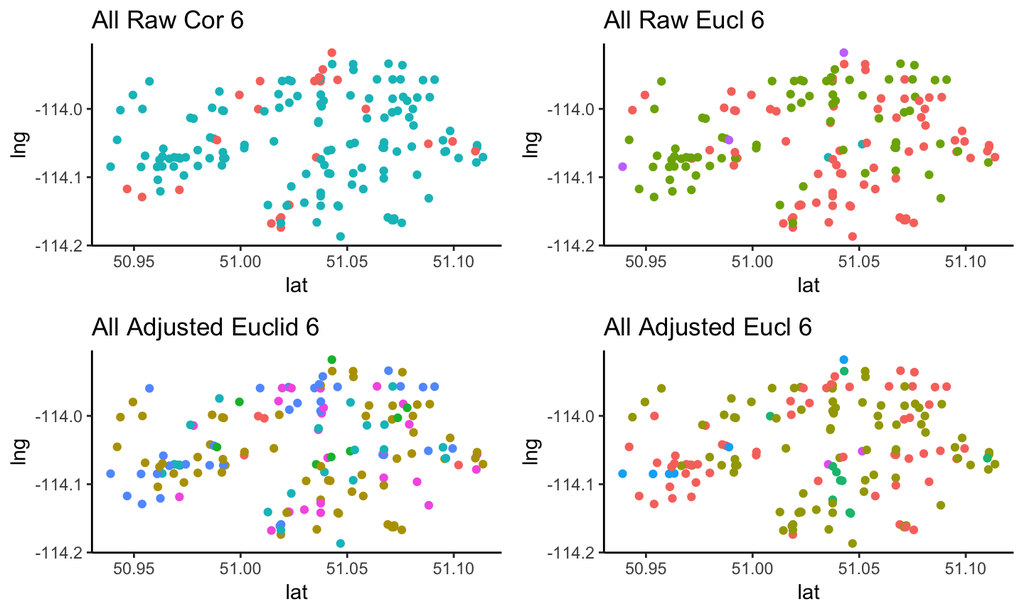

## Comparison to Vancouver

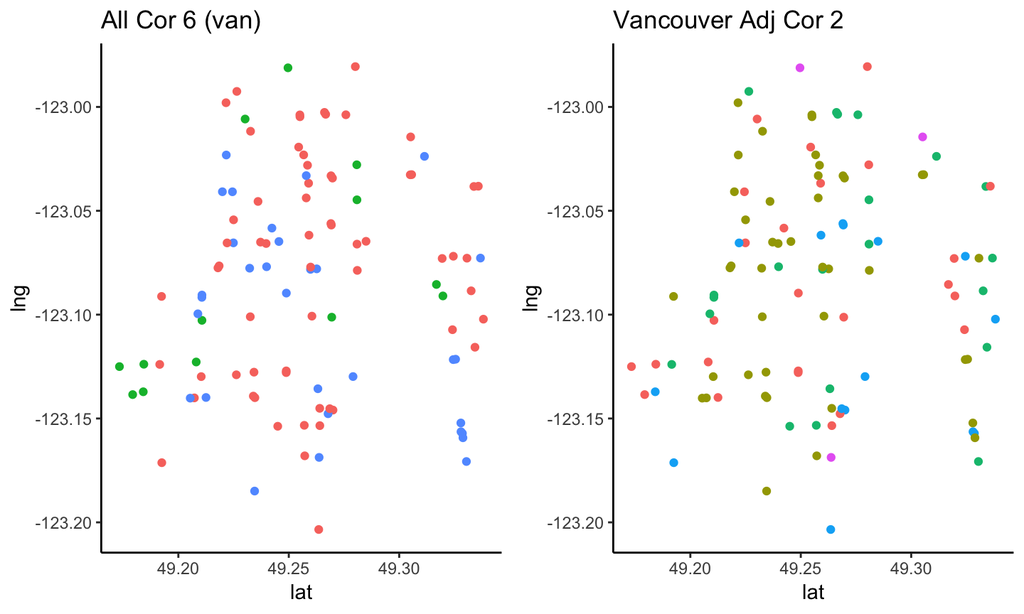

## Selection

- I will test more exhaustively in the final project
- Current analysis focuses on All Raw Euclidian 6.

*How does this perform?*

```
##            actuals
## preds       Cluster_1 Cluster_2 Cluster_3 Cluster_4 Cluster_5 Cluster_6
##   Cluster_1        32         0         0         0         0         0
##   Cluster_2         0        20         0         0         1         0
##   Cluster_3         0         0        35        17         0         0
##   Cluster_4         0         0        14        28         0         1
##   Cluster_5         0         0         0         0        12         0
##   Cluster_6         0         0         0         0         0         0
```

## Confusion Matrix

```
## Confusion Matrix and Statistics
##
##            actuals
## preds       Cluster_1 Cluster_2 Cluster_3 Cluster_4 Cluster_5 Cluster_6
##   Cluster_1        32         0         0         0         0         0
##   Cluster_2         0        20         0         0         1         0
##   Cluster_3         0         0        35        17         0         0
##   Cluster_4         0         0        14        28         0         1
##   Cluster_5         0         0         0         0        12         0
##   Cluster_6         0         0         0         0         0         0
##
## Overall Statistics
##
##                Accuracy : 0.7938
##                  95% CI : (0.7227, 0.8536)
##     No Information Rate : 0.3062
##     P-Value [Acc > NIR] : < 2.2e-16
##
##                   Kappa : 0.7295
##  Mcnemar's Test P-Value : NA
##
## Statistics by Class:
##
##                      Class: Cluster_1 Class: Cluster_2 Class: Cluster_3
## Sensitivity                       1.0           1.0000           0.7143
## Specificity                       1.0           0.9929           0.8468
## Pos Pred Value                    1.0           0.9524           0.6731
## Neg Pred Value                    1.0           1.0000           0.8704
## Prevalence                        0.2           0.1250           0.3063
## Detection Rate                    0.2           0.1250           0.2188
## Detection Prevalence              0.2           0.1313           0.3250
## Balanced Accuracy                 1.0           0.9964           0.7806
##                      Class: Cluster_4 Class: Cluster_5 Class: Cluster_6
## Sensitivity                    0.6222          0.92308          0.00000
## Specificity                    0.8696          1.00000          1.00000
## Pos Pred Value                 0.6512          1.00000              NaN
## Neg Pred Value                 0.8547          0.99324          0.99375
## Prevalence                     0.2812          0.08125          0.00625
## Detection Rate                 0.1750          0.07500          0.00000
## Detection Prevalence           0.2687          0.07500          0.00000
## Balanced Accuracy              0.7459          0.96154          0.50000
```

## Next Best Alternative

Taking the most common lable by city:

```
##             raw_eucl_6.y
## raw_eucl_6.x Cluster_1 Cluster_2 Cluster_3 Cluster_5
##    Cluster_1       107         1         1         0
##    Cluster_2         0        67         0         0
##    Cluster_3         0         0       165         0
##    Cluster_4         0         0       150         0
##    Cluster_5         0         9         3        32
##    Cluster_6         0         0         6         0
```

```
## [1] "The accuracy is: 0.685767097966728"
```

## Results

**Not Great**

## Individal Cities

Taking the most promissing result for Calgary, the adjusted correlation 2

```
##            actuals
## preds       Cluster_1 Cluster_2
##   Cluster_1        15        11
##   Cluster_2         7        13
```

## Analysis

If we chose the most common lable in calgary we get:

```
##    calg_adj_cor_2 count_calg
## 1:      Cluster_2         82
## 2:      Cluster_1         74
```

This suggests that aggrigating over entire markets only captures the market, not the sub markets.

## Increase K

If we increase K to 5:

```
## [1] "The Accuracy Table is:"
```

```
##            actuals
## preds       Cluster_1 Cluster_2 Cluster_3 Cluster_4 Cluster_5
##   Cluster_1         0         0         0         0         0
##   Cluster_2         0         0         0         0         0
##   Cluster_3         0         2         6         2         1
##   Cluster_4         3         1         3        19         8
##   Cluster_5         0         0         0         0         0
```

## Confusion Matrix

For K=5 for Calgary

```
## Confusion Matrix and Statistics
##
##            actuals
## preds       Cluster_1 Cluster_2 Cluster_3 Cluster_4 Cluster_5
##   Cluster_1         0         0         0         0         0
##   Cluster_2         0         0         0         0         0
##   Cluster_3         0         2         6         2         1
##   Cluster_4         3         1         3        19         8
##   Cluster_5         0         0         0         0         0
##
## Overall Statistics
##
##                Accuracy : 0.5556
##                  95% CI : (0.4, 0.7036)
##     No Information Rate : 0.4667
##     P-Value [Acc > NIR] : 0.1479
##
##                   Kappa : 0.2574
##  Mcnemar's Test P-Value : NA
##
## Statistics by Class:
##
##                      Class: Cluster_1 Class: Cluster_2 Class: Cluster_3
## Sensitivity                   0.00000          0.00000           0.6667
## Specificity                   1.00000          1.00000           0.8611
## Pos Pred Value                    NaN              NaN           0.5455
## Neg Pred Value                0.93333          0.93333           0.9118
## Prevalence                    0.06667          0.06667           0.2000
## Detection Rate                0.00000          0.00000           0.1333
## Detection Prevalence          0.00000          0.00000           0.2444
## Balanced Accuracy             0.50000          0.50000           0.7639
##                      Class: Cluster_4 Class: Cluster_5
## Sensitivity                    0.9048              0.0
## Specificity                    0.3750              1.0
## Pos Pred Value                 0.5588              NaN
## Neg Pred Value                 0.8182              0.8
## Prevalence                     0.4667              0.2
## Detection Rate                 0.4222              0.0
## Detection Prevalence           0.7556              0.0
## Balanced Accuracy              0.6399              0.5
```

## Analysis

If we chose the most common lable in calgary we get:

```
##    calg_adj_cor_5 count_calg
## 1:      Cluster_4         71
## 2:      Cluster_5         30
## 3:      Cluster_3         33
## 4:      Cluster_2         11
## 5:      Cluster_1         11
```

## Issues

There are several issues that I faced that might hide a different result.

- The data collection was spoty due to AWS
- GasBuddy does not have very granular pricing
- Since no company to my knowlege tries to set prices at the neighborhood level there could still be potential gains from trying too.

## Results

While the cluster analysis worked well defining different cities, it was a poor predictor of within city markets.

**Explanation**

## Further Work

See hierarchies